# Mexico: A Populous Nation with a Dynamic Demographic Landscape

An Overview of Mexico’s Population Dynamics since 1950

python

Author

Jesus L. Monroy

Published

Mar, 2024

Abstract

Mexico boasts a population of nearly 130 million, ranking it as the 10th most populous country globally.  
Mexico is a highly urbanized nation, with 88% of the population residing in cities.  
This trend is expected to continue, driven by economic opportunities and infrastructure development.

## Introduction

In this article we shall see Mexico’s Population evolution over years.

```python
import numpy as np
import pandas as pd
from plotnine import *
```

```python
# Read tsv file
mex = pd.read_csv('datasets/mexico_pop.tsv', sep='\t')
# Drop spaces
mex = mex.rename(columns={'Year ':'Year','Population ':'Population','Growth Rate':'Growth rate'})
```

```python
mex.sample(5)
```

|  | Year | Population | Growth rate |
| --- | --- | --- | --- |
| 41 | 1982 | 70,656,783 | 2.06% |
| 54 | 1969 | 48,714,394 | 3.27% |
| 69 | 1954 | 30,616,896 | 2.67% |
| 42 | 1981 | 69,233,769 | 2.26% |
| 47 | 1976 | 60,452,543 | 3.00% |

```python
mex['Population'] = pd.to_numeric(mex['Population'].str.replace(',',''))
```

```python
mex['Growth rate'] = pd.to_numeric(mex['Growth rate'].str.replace('%','', regex=True))
```

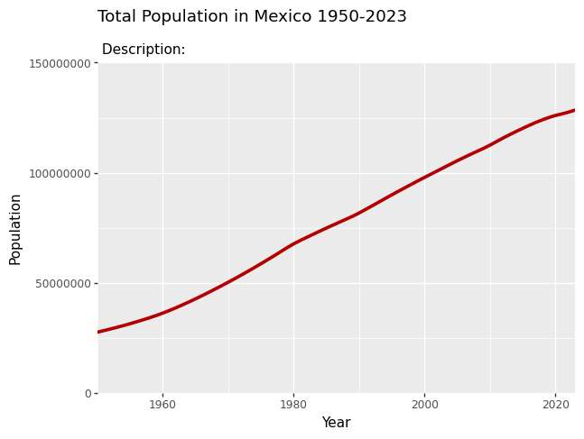

```python
(
    ggplot(mex, aes(x='Year', y='Population'))
    + geom_line(color='#b30000', size=1.5, linetype='solid')
    + labs(x='Year', y='Population',
           title='Total Population in Mexico 1950-2023',
           subtitle='\n Description:')
    + scale_y_continuous(expand=(0,0), limits=(0, 150_000_000))
    + scale_x_continuous(expand=(0,0), limits=(1950, 2023))
).draw() # Removes "<Figure Size: (640 x 480)>" below chart
```

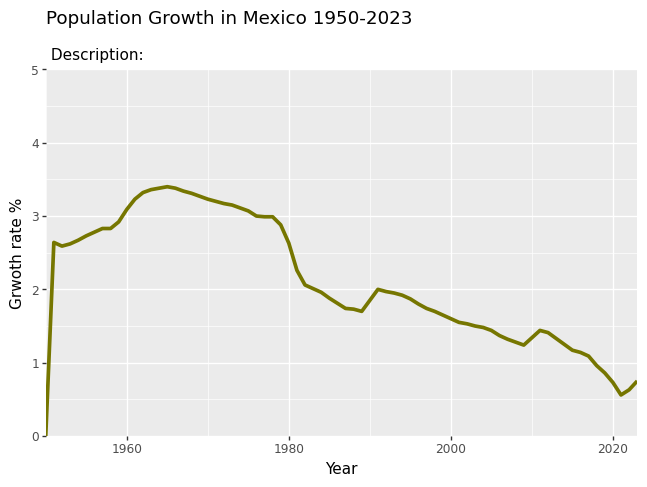

```python
(
    ggplot(mex, aes(x='Year', y='Growth rate'))
    + geom_line(color='#767600', size=1.5, linetype='solid')
    + labs(x='Year', y='Grwoth rate %',
           title='Population Growth in Mexico 1950-2023',
           subtitle='\n Description:')
    + scale_y_continuous(expand=(0,0), limits=(0, 5))
    + scale_x_continuous(expand=(0,0), limits=(1950, 2023))
).draw()
```

## Conclusions

Mexico boasts a population of nearly 130 million, ranking it as the 10th most populous country globally.

Mexico is a highly urbanized nation, with 88% of the population residing in cities. This trend is expected to continue, driven by economic opportunities and infrastructure development.

The overall population density is moderate, at around 66 individuals per square kilometer, but varies significantly across regions.

The population is relatively young, with a median age of 29.8 years. This indicates a large segment in their working years, potentially driving economic growth.

However, an aging population is expected in the coming decades, requiring adjustments to social security and healthcare systems.

Mexico is a multicultural nation with a rich indigenous heritage. While mestizos (mixed Indigenous and European ancestry) form the majority, Indigenous groups still comprise a significant portion of the population, contributing to cultural diversity.

Rapid urbanization brings challenges like managing infrastructure, providing essential services, and tackling inequality.

Investing in education, healthcare, and job creation can harness the demographic dividend presented by the young population.

Addressing the potential impact of an aging population and promoting sustainable development are crucial for long-term prosperity.

## References

- [Worldometer](https://www.worldometers.info/world-population/mexico-population/)
- [INEGI - National Institute of Statistics and Geography](https://www.inegi.org.mx/)
- [CIA World Factbook](https://www.cia.gov/the-world-factbook/countries/mexico/)

## Contact

**Jesus L. Monroy**  
*Economist & Data Scientist*

[Medium](https://medium.com/@jesuslm) | [Linkedin](https://www.linkedin.com/in/j3sus-lm) | [Twitter](https://x.com/j3suslm)